# Eigenvalues and Eigenvectors

This notebook contains examples illustrating how eignevalues and eigenvectors derived from a transformation matrix (denoted $\mathbf{A}$) can be used to illustrate distortion of a unit circle.

# Load `ggplot2` Package

```r
library(ggplot2)
```

# Unit Circle

Generate a sequence of 200 coordinate pairs, where $(x, y) = (\cos{\theta}, \sin{\theta})$.

```r
# Generate points
theta <- seq(0, 2 * pi, length.out = 200)
unit_circle <- cbind(cos(theta), sin(theta))

# Combine into a data frame
df_unit_circle <-  data.frame(x = unit_circle[ ,1], y = unit_circle[ ,2], type = "Unit Circle")
```

Let’s plot the unit circle using the coordinates we generated above.

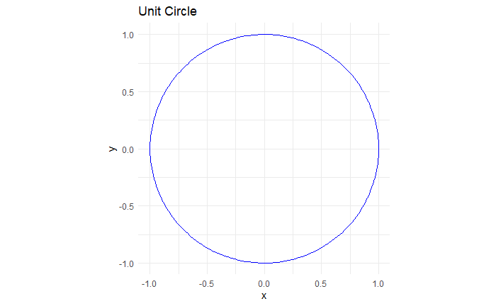

```r
ggplot() +
    geom_path(data = df_unit_circle, aes(x,y), color = "blue") +
    coord_equal() +
    theme_minimal() +
    ggtitle("Unit Circle")
```

# Create a Distorted Ellipse

We’ll provide various transformation matrixes and use their eigenvalues and eigenvectors to visualize distortion to the unit circle. We’ll begin with the simplest example (no change), then work our way up to more complex transformations.

## Set Up Function

Before we begin walking through examples, we will set up a function to perform the key steps for each scenario. The `distort` function below will display the transformation matrix, its eigenvalues and eigenvectors, and it will draw the original unit circle and the distorted ellipse.

```r
distort <- function(A) {
    # Display transformation matrix
    cat("Transformation Matrix:\n")
    print(A)
    cat("\n")

    # Perform spectra decomposition of transformation matrix
    eig <- eigen(A)

    # Display eigenvalues and eigenvectors of transformation matrix
    cat("Eigenvalues and Eigenvectors of A:\n")
    print(eig)
    cat("\n")

    # Calculate values for ellipse
    ellipse <- t(A %*% t(unit_circle))

    # Set up data frame for plot
    df_ellipse <- data.frame(x = ellipse[,1], y = ellipse[,2], type = "Ellipse")

    # Vectors for plot
    vecs <- data.frame(
        x = c(0, 0),
        y = c(0, 0),
        xend = eig$vectors[1,] * eig$values,
        yend = eig$vectors[2,] * eig$values
    )

    # Display vector coordinates
    cat("Plot Vectors:\n")
    cat("(eigenvector[i, ] * eigenvalues)\n")
    print(as.matrix(vecs))

    # Plot
    ggplot() +
        geom_path(data = df_unit_circle, aes(x, y), color = "blue") +
        geom_path(data = df_ellipse, aes(x, y), color = "red") +
        geom_segment(data = vecs, aes(x = x, y = y, xend = xend, yend = yend),
            arrow = arrow(length = unit(0.2, "cm")), color = "darkgreen", linewidth = 1) +
        coord_equal() +
        theme_minimal() +
        ggtitle("Blue = Original, Red = Transformed")
}
```

## Example 1: Identity Matrix

Let’s start off easy with a simple identity matrix. We will use the function we defined above in this and all subsequent examples.

```
Transformation Matrix:
     [,1] [,2]
[1,]    1    0
[2,]    0    1

Eigenvalues and Eigenvectors of A:
eigen() decomposition
$values
[1] 1 1

$vectors
     [,1] [,2]
[1,]    0   -1
[2,]    1    0


Plot Vectors:
(eigenvector[i, ] * eigenvalues)
     x y xend yend
[1,] 0 0    0    1
[2,] 0 0   -1    0
```

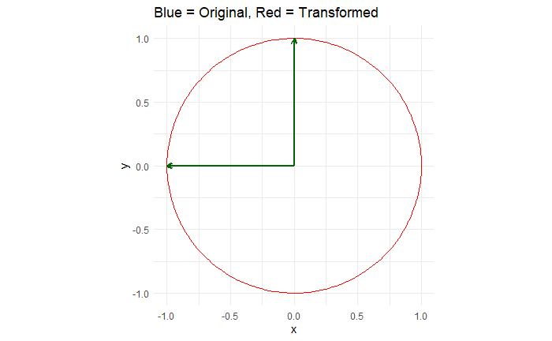

```r
matrix_1 <- matrix(
    c(
        1, 0,
        0, 1
    ),
    nrow = 2,
    byrow = TRUE
)

distort(matrix_1)
```

## Example 2: Distort X-Axis Only

Let’s stretch out the x-axis to double its original width and leave the y-axis unchanged.

```
Transformation Matrix:
     [,1] [,2]
[1,]    2    0
[2,]    0    1

Eigenvalues and Eigenvectors of A:
eigen() decomposition
$values
[1] 2 1

$vectors
     [,1] [,2]
[1,]   -1    0
[2,]    0   -1


Plot Vectors:
(eigenvector[i, ] * eigenvalues)
     x y xend yend
[1,] 0 0   -2    0
[2,] 0 0    0   -1
```

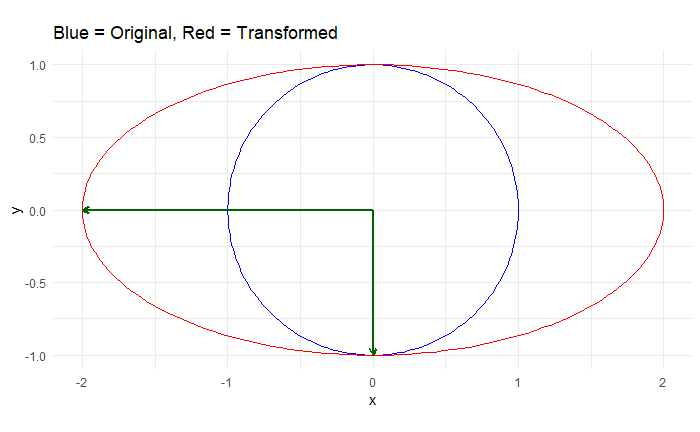

```r
matrix_2 <- matrix(
    c(
        2, 0,
        0, 1
    ),
    nrow = 2,
    byrow = TRUE
)

distort(matrix_2)
```

## Example 3: Expand Both X and Y Axes

Now let’s triple the width of the x-axis and double the height of the y-axis.

```
Transformation Matrix:
     [,1] [,2]
[1,]    3    0
[2,]    0    2

Eigenvalues and Eigenvectors of A:
eigen() decomposition
$values
[1] 3 2

$vectors
     [,1] [,2]
[1,]   -1    0
[2,]    0   -1


Plot Vectors:
(eigenvector[i, ] * eigenvalues)
     x y xend yend
[1,] 0 0   -3    0
[2,] 0 0    0   -2
```

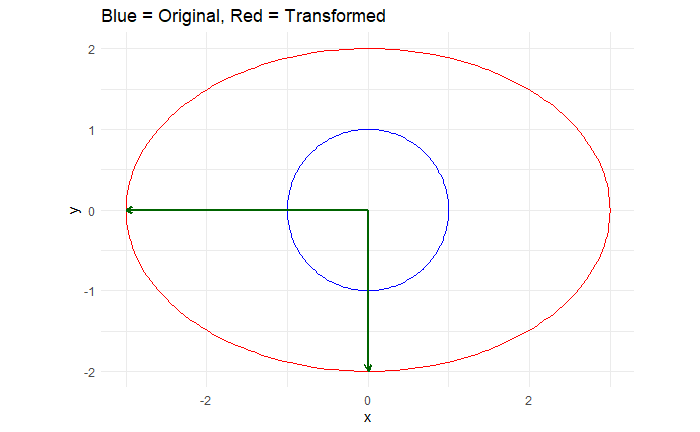

```r
matrix_3 <- matrix(
    c(
        3, 0,
        0, 2
    ),
    nrow = 2,
    byrow = TRUE
)

distort(matrix_3)
```

## Example 4: Distort and Stretch

Now, let’s play with the off-diagonal elements of $\mathbf{A}$ to produce an ellipse that is stretched and rotated.

```
Transformation Matrix:
     [,1] [,2]
[1,]    3    1
[2,]    1    2

Eigenvalues and Eigenvectors of A:
eigen() decomposition
$values
[1] 3.618034 1.381966

$vectors
           [,1]       [,2]
[1,] -0.8506508  0.5257311
[2,] -0.5257311 -0.8506508


Plot Vectors:
(eigenvector[i, ] * eigenvalues)
     x y       xend      yend
[1,] 0 0 -3.0776835 -1.902113
[2,] 0 0  0.7265425 -1.175571
```

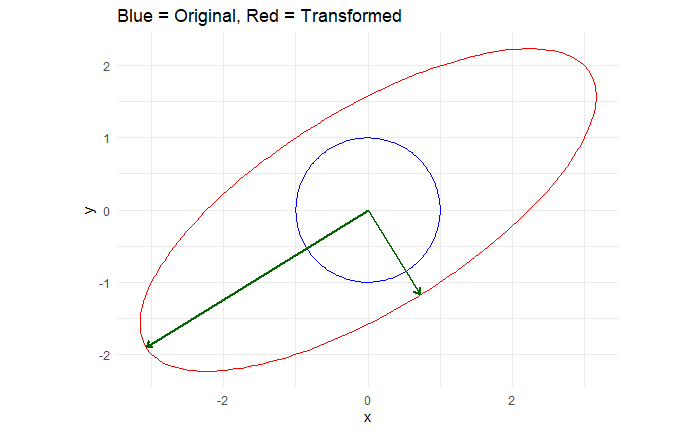

```r
matrix_4 <- matrix(
    c(
        3, 1,
        1, 2
    ),
    nrow = 2,
    byrow = TRUE
)

distort(matrix_4)
```